# CARET_Lab

2023-12-03

Package loading

```r
library(caret)
```

Load Data

```r
# attach the iris dataset to the environment
data(iris)
# rename the dataset
dataset <- iris
```

Task1: Create a Validation/Training Dataset You need to split the loaded dataset into two, 80% of which we will use to train our models and 20% that we will hold back as a validation dataset. Hint: use createDataPartition function

```r
set.seed(43)
index <- createDataPartition(dataset$Species, p = 0.8, list = FALSE)
train_data <- dataset[index, ]
validation_data <- dataset[-index, ]
```

Task2: Summarize Dataset Use skimr library to summarize the dataset

```r
library(skimr)
summary <- skim(dataset)
summary
```

Data summary

| Name | dataset |
| --- | --- |
| Number of rows | 150 |
| Number of columns | 5 |
| _______________________ |  |
| Column type frequency: |  |
| factor | 1 |
| numeric | 4 |
| ________________________ |  |
| Group variables | None |

**Variable type: factor**

| skim_variable | n_missing | complete_rate | ordered | n_unique | top_counts |
| --- | --- | --- | --- | --- | --- |
| Species | 0 | 1 | FALSE | 3 | set: 50, ver: 50, vir: 50 |

**Variable type: numeric**

| skim_variable | n_missing | complete_rate | mean | sd | p0 | p25 | p50 | p75 | p100 | hist |
| --- | --- | --- | --- | --- | --- | --- | --- | --- | --- | --- |
| Sepal.Length | 0 | 1 | 5.84 | 0.83 | 4.3 | 5.1 | 5.80 | 6.4 | 7.9 | ▆▇▇▅▂ |
| Sepal.Width | 0 | 1 | 3.06 | 0.44 | 2.0 | 2.8 | 3.00 | 3.3 | 4.4 | ▁▆▇▂▁ |
| Petal.Length | 0 | 1 | 3.76 | 1.77 | 1.0 | 1.6 | 4.35 | 5.1 | 6.9 | ▇▁▆▇▂ |
| Petal.Width | 0 | 1 | 1.20 | 0.76 | 0.1 | 0.3 | 1.30 | 1.8 | 2.5 | ▇▁▇▅▃ |

Task3: split input and output It is the time to seperate the input attributes and the output attributes. call the inputs attributes x and the output attribute (or class) y.

```r
x <- dataset[ , 1:4]
y <- dataset$Species
head(x)
```

```
##   Sepal.Length Sepal.Width Petal.Length Petal.Width
## 1          5.1         3.5          1.4         0.2
## 2          4.9         3.0          1.4         0.2
## 3          4.7         3.2          1.3         0.2
## 4          4.6         3.1          1.5         0.2
## 5          5.0         3.6          1.4         0.2
## 6          5.4         3.9          1.7         0.4
```

```r
head(y)
```

```
## [1] setosa setosa setosa setosa setosa setosa
## Levels: setosa versicolor virginica
```

Task4: Train Control for Validation Test

We will use 10-fold crossvalidation to estimate accuracy.

```r
# Run algorithms using 10-fold cross validation
control <- trainControl(method="cv", number=10)
metric <- "Accuracy"
```

Task5: Model Training Train 5 different algorithms using ‘train’ function:

- Linear Discriminant Analysis (LDA)
- Classification and Regression Trees (CART).
- k-Nearest Neighbors (kNN).
- Support Vector Machines (SVM) with a linear kernel.
- Random Forest (RF)

```r
library(caret)
library(MASS)          # For LDA
library(rpart)         # For CART
library(class)         # For kNN
library(e1071)         # For SVM
library(randomForest)  # For RF
# Linear Discriminant Analysis (LDA)
lda_model <- train(x, y, method = "lda", metric = metric, trControl = control)
```

```r
# Classification and Regression Trees (CART)
cart_model <- train(x, y, method = "rpart", metric = metric, trControl = control)
```

```r
# k-Nearest Neighbors (kNN)
knn_model <- train(x, y, method = "knn", metric = metric, trControl = control)
```

```r
# Support Vector Machines (SVM) with a linear kernel
svm_model <- train(x, y, method = "svmLinear", metric = metric, trControl = control)
```

```r
# Random Forest (RF)
rf_model <- train(x, y, method = "rf", metric = metric, trControl = control)
```

Task6: Select the Best Model We now have 5 models and accuracy estimations for each. We need to compare the models to each other and select the most accurate. Use resamples function to complete this task

```r
models <- list(
  LDA = lda_model,
  CART = cart_model,
  kNN = knn_model,
  SVM = svm_model,
  RF = rf_model)

resamps <- resamples(models)
summary(resamps)
```

```
##
## Call:
## summary.resamples(object = resamps)
##
## Models: LDA, CART, kNN, SVM, RF
## Number of resamples: 10
##
## Accuracy
##           Min.   1st Qu.    Median      Mean   3rd Qu. Max. NA's
## LDA  0.9333333 0.9500000 1.0000000 0.9800000 1.0000000    1    0
## CART 0.8000000 0.8833333 0.9333333 0.9266667 0.9833333    1    0
## kNN  0.9333333 0.9500000 1.0000000 0.9800000 1.0000000    1    0
## SVM  0.8666667 0.9500000 1.0000000 0.9733333 1.0000000    1    0
## RF   0.8666667 0.9333333 0.9333333 0.9533333 1.0000000    1    0
##
## Kappa
##      Min. 1st Qu. Median Mean 3rd Qu. Max. NA's
## LDA   0.9   0.925    1.0 0.97   1.000    1    0
## CART  0.7   0.825    0.9 0.89   0.975    1    0
## kNN   0.9   0.925    1.0 0.97   1.000    1    0
## SVM   0.8   0.925    1.0 0.96   1.000    1    0
## RF    0.8   0.900    0.9 0.93   1.000    1    0
```

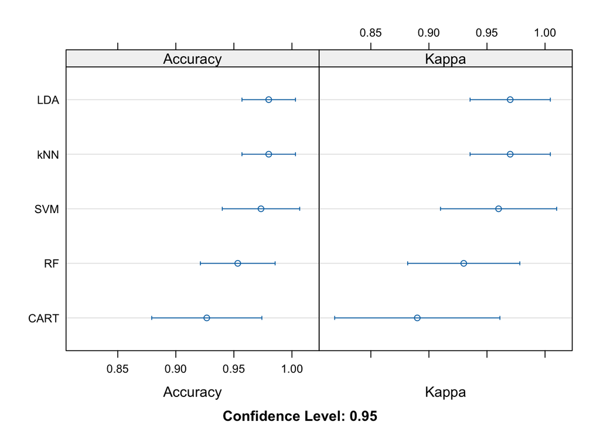

```r
dotplot(resamps)
```

Task7: Make Prediction (Confusion Matrix) Now we want to get an idea of the accuracy of the best model on our validation set. Use ‘predict’ and confusionMatrix functions to complete this task.

```r
predictions <- predict(lda_model, newdata = validation_data)
conf_matrix <- confusionMatrix(predictions, validation_data$Species)
print(conf_matrix)
```

```
## Confusion Matrix and Statistics
##
##             Reference
## Prediction   setosa versicolor virginica
##   setosa         10          0         0
##   versicolor      0         10         0
##   virginica       0          0        10
##
## Overall Statistics
##
##                Accuracy : 1
##                  95% CI : (0.8843, 1)
##     No Information Rate : 0.3333
##     P-Value [Acc > NIR] : 4.857e-15
##
##                   Kappa : 1
##
##  Mcnemar's Test P-Value : NA
##
## Statistics by Class:
##
##                      Class: setosa Class: versicolor Class: virginica
## Sensitivity                 1.0000            1.0000           1.0000
## Specificity                 1.0000            1.0000           1.0000
## Pos Pred Value              1.0000            1.0000           1.0000
## Neg Pred Value              1.0000            1.0000           1.0000
## Prevalence                  0.3333            0.3333           0.3333
## Detection Rate              0.3333            0.3333           0.3333
## Detection Prevalence        0.3333            0.3333           0.3333
## Balanced Accuracy           1.0000            1.0000           1.0000
```